# Real-world effectiveness and safety of risankizumab in patients with moderate-to-severe multi-refractory Crohn’s disease: a Belgian multi-centric cohort study

Author

Dahham Alsoud

Published

August 20, 2023

Modified

March 10, 2024

The aim of this analysis notebook is to reproduce the reported analysis in the paper `Real-world effectiveness and safety of risankizumab in patients with moderate-to-severe multi-refractory Crohn's disease: a Belgian multi-centric cohort study`.

To run the analysis, we assume that you already have the raw data file, named `realworld-risankizumab-belgium.xlsx`, in the `input` folder, within the home directory of your project.

This raw data file can be obtained upon reasonable request to the corresponding author, [Marc Ferrante](https://www.uzleuven.be/en/physicians-and-specialists/marc-ferrante), via marc.ferrante@uzleuven.be.

## 1. Install and load needed packages, and write an S3 method for printing tables

```r
if (!require(pacman)) install.packages("pacman")
pacman::p_load(here, rio, magrittr, janitor, tidyverse, rstatix, gtsummary, huxtable,flextable, ggsurvfit, survival)

devtools::install_github("DahhamAlsoud/phdcocktail")
devtools::install_github("MSKCC-Epi-Bio/bstfun")

pacman::p_load(bstfun, phdcocktail)
```

```r
print.data.frame <- function(df) {
  df %>% flextable::flextable() %>% flextable::align(part = "all", align = "center") %>% flextable::autofit()
}

print.tabyl <- function(df) {
  df %>% flextable::flextable() %>% flextable::align(part = "all", align = "center") %>% flextable::autofit()
}

print.tbl <- function(df) {
  df %>% flextable::flextable() %>% flextable::align(part = "all", align = "center") %>% flextable::autofit()
}
```

## 2. Import raw data

We will now import the raw data. There are 3 rows for each patient: baseline, week 24 and week 52. We will filter the dataframe to only the “baseline” rows as these contain the baseline characteristics, and the outcomes. We will also filter out excluded patients.

```r
input_file <- import(here("input", "realworld-risankizumab-belgium.xlsx")) %>% clean_names()
input_file_baseline <- input_file[input_file$visit_timepoint == "baseline" & input_file$excluded == 0 ,]
```

## 3. Pre-process raw data and get general info about the included cohort

### Pre-process variables

We will transform some variables and generate some new ones which we will need later to construct our `Table 1`, or to be reported in the results/abstract.

```r
continuous_vrs <- c("age_yrs", "age_at_diagnosis_yrs", "disease_duration_yrs", "bmi_kg_m2", "crp_mg_l", "calprotectin_ug_g", "ses_cd")

input_file_baseline %<>% mutate(across(all_of(continuous_vrs), ~ round(as.numeric(.), 1)))

input_file_baseline %<>% mutate(female_gender = if_else(gender == "F", 1, 0), .after = gender)

input_file_baseline %<>% mutate(current_smoker = if_else(smoking == 1, 1, 0), .after = smoking)

input_file_baseline %<>% mutate(age_montreal = case_when(
  age_at_diagnosis_yrs < 17 ~ "A1",
  age_at_diagnosis_yrs > 40 ~ "A3",
  .default = "A2"
), .after = age_at_diagnosis_yrs)

input_file_baseline %<>% mutate(concomitant_cs = case_when(
  concomitant_cs == "0" ~ "no",
  str_detect(concomitant_cs, regex("medrol", ignore_case = TRUE)) ~ "sys",
  .default = "top"
))

input_file_baseline %<>% mutate(concomitant_imm = if_else(concomitant_imm == "0", 0, 1))

input_file_baseline %<>% mutate(concomitant_5asa = if_else(concomitant_5asa == "0", 0, 1))

input_file_baseline %<>% mutate(concomitant_advanced = if_else(concomitant_advanced == "0", 0, 1))

input_file_baseline %<>% mutate(three_advanced = if_else(amount_previous_advanced > 2, 1, 0), .after = amount_previous_advanced)

input_file_baseline %<>% mutate(four_advanced = if_else(amount_previous_advanced > 3, 1, 0), .after = amount_previous_advanced)

input_file_baseline %<>% mutate(five_advanced = if_else(amount_previous_advanced > 4, 1, 0), .after = amount_previous_advanced)

input_file_baseline %<>% mutate(any_resection_before = if_else(previous_ileocaecal_resection == 1 | other_surgery_before == 1, 1, 0), .after = previous_ileocaecal_resection)
```

### Get general info about the included cohort

*calculate number of included/excluded patients*

```r
input_file %>%
  filter(visit_timepoint == "baseline") %>%
  tabyl(excluded) %>%
  adorn_pct_formatting(digits = 2) %>% print()
```

| excluded | n | percent |
| --- | --- | --- |
| 0 | 69 | 93.24% |
| 1 | 5 | 6.76% |

*calculate number of included patients with/without ostomy*

```r
input_file_baseline %>%
  tabyl(stoma_at_start) %>%
  adorn_pct_formatting(digits = 2) %>% print()
```

| stoma_at_start | n | percent |
| --- | --- | --- |
| 0 | 55 | 79.71% |
| 1 | 14 | 20.29% |

*calculate % female in the included cohort*

```r
input_file_baseline %>%
  tabyl(gender) %>%
  adorn_pct_formatting(digits = 2) %>% print()
```

| gender | n | percent |
| --- | --- | --- |
| F | 39 | 56.52% |
| M | 30 | 43.48% |

*calculate median age for the included cohort*

```r
print(report_quantiles(input_file_baseline, summary_vrs = "age_yrs"))
```

```
median (IQR) age_yrs was 37.2 (29.5-49)
```

## 4. Present baseline characteristics (i.e. make Table 1)

We will define which variables we would like to include in our `Table 1`, recode them, and finally present them.

```r
tableone_df <- input_file_baseline %>%
  select(stoma_at_start, female_gender, age_yrs, disease_duration_yrs, current_smoker, bmi_kg_m2, crp_mg_l, calprotectin_ug_g, ses_cd, age_montreal,
         disease_location, upper_gi_disease, disease_behaviour, peri_anal_disease, current_fibrostenosing, current_penetrating, any_resection_before,
         concomitant_cs, concomitant_imm, concomitant_5asa, concomitant_advanced, three_advanced, four_advanced, five_advanced, previous_ustekinumab, reason_stop_ust)

tableone_df$stoma_at_start <- if_else(tableone_df$stoma_at_start == 0, "Without an ostomy", "With an ostomy") %>% factor(., levels = c("Without an ostomy", "With an ostomy"))

categorical_vrs = c("age_montreal", "disease_location", "disease_behaviour", "concomitant_cs", "reason_stop_ust")

tableone_df_recoded <- recode_vrs(tableone_df, data_dictionary = ibd_data_dict, vrs = categorical_vrs, factor = TRUE)

dichotomous_vrs <- base::setdiff(names(tableone_df), c(categorical_vrs, continuous_vrs))[-1]


theme_gtsummary_journal(journal = "jama")
theme_gtsummary_compact()

tableone <- tableone_df_recoded %>%
  tbl_summary(by = stoma_at_start,
              type = list(any_of(continuous_vrs) ~ "continuous",
                          any_of(categorical_vrs) ~ "categorical",
                          any_of(dichotomous_vrs) ~ "dichotomous"),
              missing_text = "missing, n",
              digits = list(all_categorical() ~ c(0, 1))) %>%
  modify_header(label = "**Baseline characteristic**",
                stat_1 = "**Without an ostomy<br />(n = 55)**",
                stat_2 = "**With an ostomy<br />(n = 14)**")

tableone <- tableone %>%
  add_variable_grouping(
    "Previous number of advanced therapies, n (%)" = c("three_advanced", "four_advanced", "five_advanced")
  )

labels_to_levels <- c("upper_gi_disease", "peri_anal_disease", "three_advanced", "four_advanced", "five_advanced")

tableone_body <- tableone[["table_body"]]

tableone_body$row_type[tableone_body$variable %in% labels_to_levels] <- "level"

tableone_body$stat_label[tableone_body$variable %in% labels_to_levels] <- NA

tableone_body <- tableone_body[tableone_body$label != "None",]

tableone_body <- tableone_body[-which(tableone_body$variable == "reason_stop_ust" & tableone_body$row_type == "missing"),]

tableone[["table_body"]]  <- tableone_body

tableone <- tableone %>%
  bold_labels() %>%
  italicize_levels()

tableone
```

| **Baseline characteristic** | Without an ostomy (n = 55) | With an ostomy (n = 14) |
| --- | --- | --- |
| Female, n (%) | 32 (58.2) | 7 (50.0) |
| Age (year), Median (IQR) | 39 (30 – 50) | 34 (26 – 43) |
| Disease duration (year), Median (IQR) | 17 (10 – 24) | 16 (11 – 21) |
| Current smoking, n (%) | 8 (14.8) | 2 (14.3) |
| missing, n | 1 | 0 |
| Body mass index (kg/m²), Median (IQR) | 23.6 (19.7 – 27.0) | 21.7 (18.9 – 24.1) |
| C-reactive protein (mg/L), Median (IQR) | 10 (4 – 25) | 21 (8 – 52) |
| missing, n | 6 | 1 |
| Faecal calprotectin (ug/g), Median (IQR) | 955 (484 – 1,800) | 1,038 (656 – 1,419) |
| missing, n | 30 | 12 |
| Simple endoscopic score for Crohn's disease, Median (IQR) | 10 (7 – 16) | 11 (8 – 19) |
| missing, n | 19 | 5 |
| Age at diagnosis (year), n (%) |  |  |
| < 17 years | 18 (32.7) | 8 (57.1) |
| 17-40 years | 30 (54.5) | 6 (42.9) |
| > 40 years | 7 (12.7) | 0 (0.0) |
| Disease location, n (%) |  |  |
| Ileal | 7 (12.7) | 1 (7.1) |
| Colonic | 9 (16.4) | 2 (14.3) |
| Ileocolonic | 39 (70.9) | 11 (78.6) |
| Upper GI modifier | 11 (20.0) | 3 (21.4) |
| Disease behaviour, n (%) |  |  |
| Inflammatory | 18 (32.7) | 3 (21.4) |
| Fibrostenotic | 25 (45.5) | 7 (50.0) |
| Penetrating | 12 (21.8) | 4 (28.6) |
| Perianal modifier | 24 (43.6) | 10 (71.4) |
| Current fibrostenosing complications, n (%) | 10 (18.2) | 4 (28.6) |
| Current penetrating complications, n (%) | 1 (1.8) | 1 (7.1) |
| Previous CD-related intestinal resection, n (%) | 33 (60.0) | 8 (57.1) |
| Concomitant corticosteroids, n (%) |  |  |
| Topical | 8 (14.5) | 1 (7.1) |
| Systemic | 10 (18.2) | 1 (7.1) |
| Concomitant immunomodulators, n (%) | 6 (10.9) | 3 (21.4) |
| Concomitant 5-aminosalicylates, n (%) | 2 (3.6) | 0 (0.0) |
| Concomitant advanced therapies, n (%) | 3 (5.5) | 2 (14.3) |
| Previous number of advanced therapies, n (%) |  |  |
| ≥ 3 | 52 (94.5) | 14 (100.0) |
| ≥ 4 | 46 (83.6) | 13 (92.9) |
| ≥ 5 | 16 (29.1) | 5 (35.7) |
| Previous ustekinumab, n (%) | 54 (98.2) | 14 (100.0) |
| Reason for ustekinumab discontinuation, n (%) |  |  |
| Loss of response | 34 (63.0) | 8 (57.1) |
| Primary non-response | 20 (37.0) | 3 (21.4) |
| Adverse events | 0 (0.0) | 3 (21.4) |

## 5. Survival analysis & dose optimizations

*generate few “time” variables which we will need for further calculations*

```r
input_file_baseline %<>% mutate(persistence_duration = round(as.numeric(date_stop_or_surgery - visit_date, "weeks"), 1), .after = date_stop_or_surgery)

input_file_baseline %<>% mutate(time_to_optimize = round(as.numeric(date_dose_optimization - visit_date, "weeks"), 1), .after = date_dose_optimization)

input_file_baseline %<>% mutate(followup_duration = round(as.numeric(date_last_infusion - visit_date, "weeks"), 1), .after = date_last_infusion)
```

*calculate follow-up duration*

```r
print(report_quantiles(input_file_baseline, summary_vrs = "followup_duration"))
```

```
median (IQR) followup_duration was 68.3 (51.9-98.4)
```

*check how many patients stopped risankizumab and why*

```r
input_file_baseline %>%
  tabyl(stop_current_treatment, reason_stop) %>% print()
```

| stop_current_treatment | LOF | LOR | PNR | NA_ |
| --- | --- | --- | --- | --- |
| 0 | 0 | 0 | 0 | 54 |
| 1 | 2 | 7 | 6 | 0 |

*calculate time to stop in patients with PNR/LOR*

```r
print(report_quantiles(input_file_baseline[input_file_baseline$reason_stop %in% c("LOR", "PNR"),], summary_vrs = "persistence_duration"))
```

```
median (IQR) persistence_duration was 43.1 (29.6-55.9)
```

*check how many of these stops were during the first 52 weeks of follow-up*

```r
input_file_baseline %>%
  filter(stop_current_treatment == 1) %>%
  count(reason_stop, during_w52 = followup_duration <=52) %>% print()
```

| reason_stop | during_w52 | n |
| --- | --- | --- |
| LOF | TRUE | 2 |
| LOR | FALSE | 4 |
| LOR | TRUE | 3 |
| PNR | TRUE | 6 |

### Survival analysis

*construct KM curve*

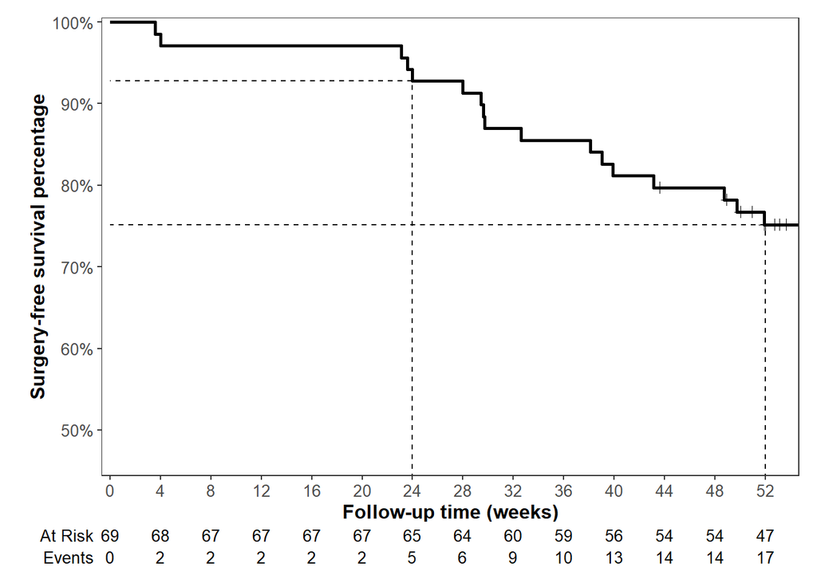

```r
persistence_km <- survfit2(Surv(persistence_duration, stop_or_surgery) ~ 1, data = input_file_baseline) %>%
  ggsurvfit(linewidth = 1) +
  add_risktable() +
  add_censor_mark() +
  coord_cartesian(xlim = c(0,54), ylim = c(0.45, 1)) +
  labs(x = "Follow-up time (weeks)", y = "Surgery-free survival percentage") +
  scale_y_continuous(label = scales::percent,
                     breaks = seq(0, 1, by = 0.1),
                     expand = c(0.01, 0)) +
  scale_x_continuous(breaks = seq(0, 54, by = 4),
                     expand = c(0.012, 0)) +
  add_quantile(linetype = 2, x_value = 24) +
  add_quantile(linetype = 2, x_value = 52) +
  theme(panel.grid = element_blank(),
        axis.title = element_text(face = "bold"))

persistence_km
```

*calculate survival probabilities*

```r
tbl_survfit <- survfit(Surv(persistence_duration, stop_or_surgery) ~ 1, input_file_baseline) %>%
  tbl_survfit(
  times = c(24, 52),
  label_header = "**Week {time}**",
  estimate_fun = function(x) style_percent(x, symbol = TRUE, digits = 1)
)

tbl_survfit
```

| **Characteristic** | **Week 24** | **Week 52** |
| --- | --- | --- |
| Overall | 92.8% (86.8% to 99.1%) | 75.2% (65.6% to 86.1%) |

### Dose optimizations

*check how many patients needed optimizations*

```r
input_file_baseline %>%
  tabyl(dose_optimization) %>%
  adorn_pct_formatting(digits = 2) %>% print()
```

| dose_optimization | n | percent |
| --- | --- | --- |
| 0 | 50 | 72.46% |
| 1 | 19 | 27.54% |

*calculate time to optimizations*

```r
print(report_quantiles(input_file_baseline, summary_vrs = "time_to_optimize"))
```

```
median (IQR) time_to_optimize was 48.7 (33.5-61.5)
```

*check how many of these optimizations were during the first 52 weeks of follow-up*

```r
input_file_baseline %>%
  filter(dose_optimization == 1) %>%
  count(during_w52 = time_to_optimize <= 52) %>% print()
```

| during_w52 | n |
| --- | --- |
| FALSE | 7 |
| TRUE | 12 |

## 6. Calculate and plot outcome data

### in patients without ostomy

#### for clinical outcomes

*calculate…*

```r
clinical_outcomes_without <- input_file_baseline %>%
  filter(stoma_at_start == 0) %>%
  select(clinical_outome_w24_itt, steroid_dependent_w24, clinical_outome_w52_itt, steroid_dependent_w52) %>%
  mutate(clinical_response_w24 = if_else(clinical_outome_w24_itt != "pnr", 1, 0),
         clinical_remission_w24 = if_else(clinical_outome_w24_itt == "rem", 1, 0),
         clinical_response_w52 = if_else(clinical_outome_w52_itt != "pnr", 1, 0),
         clinical_remission_w52 = if_else(clinical_outome_w52_itt == "rem", 1, 0), .keep = "unused")

clinical_outcomes_without %<>%
  mutate(across(all_of(c("clinical_response_w24", "clinical_remission_w24")), ~ if_else(steroid_dependent_w24 == 1, 0, .), .names = "csfree_{.col}"),
          .after = clinical_remission_w24) %>%
  mutate(across(all_of(c("clinical_response_w52", "clinical_remission_w52")), ~ if_else(steroid_dependent_w52 == 1, 0, .), .names = "csfree_{.col}"),
          .after = clinical_remission_w52) %>%
  select(matches("clinical"))

clinical_outcomes_without_long <- clinical_outcomes_without %>%
  summarise(across(matches("clinical"), ~ sum(. == 1, na.rm = T))) %>%
  pivot_longer(cols = everything(),names_to = "outcome", values_to = "achieved") %>%
  mutate(total= nrow(clinical_outcomes_without)) %>%
  mutate(timepoint = if_else(str_detect(outcome, "24"), "Week 24", "Week 52"), .after = outcome) %>%
  mutate(outcome = str_remove(outcome, "_w(\\d*)") %>%
                   str_replace_all(.,"_", " ") %>%
                   str_replace(., "csfree", "steroid-free") %>%
                   str_to_sentence()
         ) %>%
  mutate(proportion = round_half_up(achieved/total, 3),
         percentage = proportion*100,
         percentage_labelled = scales::percent(proportion))


clinical_outcomes_without_long %<>% mutate(timepoint = factor(timepoint, levels = c("Week 24", "Week 52"))) %>%
  mutate(outcome = factor(outcome, levels = c("Clinical response", "Steroid-free clinical response", "Clinical remission", "Steroid-free clinical remission")))

clinical_outcomes_without_long %>% print()
```

| outcome | timepoint | achieved | total | proportion | percentage | percentage_labelled |
| --- | --- | --- | --- | --- | --- | --- |
| Clinical response | Week 24 | 36 | 55 | 0.655 | 65.5 | 65.5% |
| Clinical remission | Week 24 | 10 | 55 | 0.182 | 18.2 | 18.2% |
| Steroid-free clinical response | Week 24 | 34 | 55 | 0.618 | 61.8 | 61.8% |
| Steroid-free clinical remission | Week 24 | 10 | 55 | 0.182 | 18.2 | 18.2% |
| Clinical response | Week 52 | 33 | 55 | 0.600 | 60.0 | 60.0% |
| Clinical remission | Week 52 | 15 | 55 | 0.273 | 27.3 | 27.3% |
| Steroid-free clinical response | Week 52 | 32 | 55 | 0.582 | 58.2 | 58.2% |
| Steroid-free clinical remission | Week 52 | 15 | 55 | 0.273 | 27.3 | 27.3% |

*then plot!*

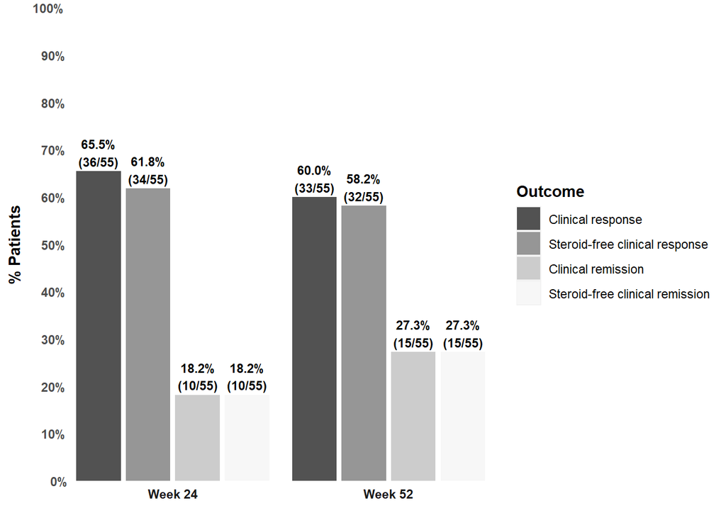

```r
clinical_bars <- plot_bars(clinical_outcomes_without_long,outcome = outcome, proportion = proportion, percentage_labelled = percentage_labelled,
           achieved = achieved, total = total, grouping = timepoint)
```

#### for endoscopic outcomes

*get the number of patients who had both baseline and follow-up endoscopy*

```r
input_file_baseline %<>%
  mutate(baseANDfollowup_endoscopy = if_else(endoscopy_baseline == 1 & endoscopy_w24orw52 == 1, 1, 0), .after = endoscopy_w24orw52)


input_file_baseline %>%
  group_by(stoma_at_start) %>%
  summarise(baseline_endoscopy = sum(endoscopy_baseline == 1),
            baseANDfollowup_endoscopy = sum(baseANDfollowup_endoscopy == 1)) %>% print()
```

| stoma_at_start | baseline_endoscopy | baseANDfollowup_endoscopy |
| --- | --- | --- |
| 0 | 42 | 32 |
| 1 | 12 | 6 |

*calculate…*

```r
endoscopic_outcomes_without <- input_file_baseline %>%
  filter(stoma_at_start == 0, baseANDfollowup_endoscopy == 1) %>%
  select(endoscopic_outcome_w24orw52) %>%
  mutate(endoscopic_response = if_else(endoscopic_outcome_w24orw52 != "pnr", 1, 0),
         endoscopic_remission = if_else(endoscopic_outcome_w24orw52 == "rem", 1, 0), .keep = "unused")


endoscopic_outcomes_without_long <- endoscopic_outcomes_without %>%
  summarise(across(matches("endoscopic"), ~ sum(. == 1, na.rm = T))) %>%
  pivot_longer(cols = everything(),names_to = "outcome", values_to = "achieved") %>%
  mutate(total= nrow(endoscopic_outcomes_without)) %>%
  mutate(outcome = str_replace_all(outcome,"_", " ") %>%
           str_to_sentence()
  ) %>%
  mutate(proportion = round_half_up(achieved/total, 3),
         percentage = proportion*100,
         percentage_labelled = scales::percent(proportion))


endoscopic_outcomes_without_long$outcome <- factor(endoscopic_outcomes_without_long$outcome, levels = c("Endoscopic response", "Endoscopic remission"))

endoscopic_outcomes_without_long %>% print()
```

| outcome | achieved | total | proportion | percentage | percentage_labelled |
| --- | --- | --- | --- | --- | --- |
| Endoscopic response | 16 | 32 | 0.500 | 50.0 | 50% |
| Endoscopic remission | 2 | 32 | 0.063 | 6.3 | 6% |

### in patients with ostomy

#### for clinical outcomes

*calculate…*

```r
clinical_outcomes_with<- input_file_baseline %>%
  filter(stoma_at_start == 1) %>%
  select(clinical_outome_w24_itt, steroid_dependent_w24, clinical_outome_w52_itt, steroid_dependent_w52) %>%
  mutate(clinical_response_w24 = if_else(clinical_outome_w24_itt != "pnr", 1, 0),
         clinical_remission_w24 = if_else(clinical_outome_w24_itt == "rem", 1, 0),
         clinical_response_w52 = if_else(clinical_outome_w52_itt != "pnr", 1, 0),
         clinical_remission_w52 = if_else(clinical_outome_w52_itt == "rem", 1, 0), .keep = "unused")

clinical_outcomes_with%<>%
  mutate(across(all_of(c("clinical_response_w24", "clinical_remission_w24")), ~ if_else(steroid_dependent_w24 == 1, 0, .), .names = "csfree_{.col}"),
         .after = clinical_remission_w24) %>%
  mutate(across(all_of(c("clinical_response_w52", "clinical_remission_w52")), ~ if_else(steroid_dependent_w52 == 1, 0, .), .names = "csfree_{.col}"),
         .after = clinical_remission_w52) %>%
  select(matches("clinical"))

clinical_outcomes_with_long <- clinical_outcomes_with%>%
  summarise(across(matches("clinical"), ~ sum(. == 1, na.rm = T))) %>%
  pivot_longer(cols = everything(),names_to = "outcome", values_to = "achieved") %>%
  mutate(total= nrow(clinical_outcomes_with)) %>%
  mutate(timepoint = if_else(str_detect(outcome, "24"), "Week 24", "Week 52"), .after = outcome) %>%
  mutate(outcome = str_remove(outcome, "_w(\\d*)") %>%
           str_replace_all(.,"_", " ") %>%
           str_replace(., "csfree", "steroid-free") %>%
           str_to_sentence()
  ) %>%
  mutate(proportion = round_half_up(achieved/total, 3),
         percentage = proportion*100,
         percentage_labelled = scales::percent(proportion))


clinical_outcomes_with_long %<>% mutate(timepoint = factor(timepoint, levels = c("Week 24", "Week 52"))) %>%
  mutate(outcome = factor(outcome, levels = c("Clinical response", "Steroid-free clinical response", "Clinical remission", "Steroid-free clinical remission")))

clinical_outcomes_with_long %>% print()
```

| outcome | timepoint | achieved | total | proportion | percentage | percentage_labelled |
| --- | --- | --- | --- | --- | --- | --- |
| Clinical response | Week 24 | 7 | 14 | 0.500 | 50.0 | 50.0% |
| Clinical remission | Week 24 | 1 | 14 | 0.071 | 7.1 | 7.1% |
| Steroid-free clinical response | Week 24 | 7 | 14 | 0.500 | 50.0 | 50.0% |
| Steroid-free clinical remission | Week 24 | 1 | 14 | 0.071 | 7.1 | 7.1% |
| Clinical response | Week 52 | 6 | 14 | 0.429 | 42.9 | 42.9% |
| Clinical remission | Week 52 | 2 | 14 | 0.143 | 14.3 | 14.3% |
| Steroid-free clinical response | Week 52 | 6 | 14 | 0.429 | 42.9 | 42.9% |
| Steroid-free clinical remission | Week 52 | 2 | 14 | 0.143 | 14.3 | 14.3% |

#### for endoscopic outcomes

*get the number of patients who had both baseline and follow-up endoscopy*

```r
input_file_baseline %>%
  group_by(stoma_at_start) %>%
  summarise(baseline_endoscopy = sum(endoscopy_baseline == 1),
            baseANDfollowup_endoscopy = sum(baseANDfollowup_endoscopy == 1)) %>% print()
```

| stoma_at_start | baseline_endoscopy | baseANDfollowup_endoscopy |
| --- | --- | --- |
| 0 | 42 | 32 |
| 1 | 12 | 6 |

*calculate…*

```r
endoscopic_outcomes_with <- input_file_baseline %>%
  filter(stoma_at_start == 1, baseANDfollowup_endoscopy == 1) %>%
  select(endoscopic_outcome_w24orw52) %>%
  mutate(endoscopic_response = if_else(endoscopic_outcome_w24orw52 != "pnr", 1, 0),
         endoscopic_remission = if_else(endoscopic_outcome_w24orw52 == "rem", 1, 0), .keep = "unused")


endoscopic_outcomes_with_long <- endoscopic_outcomes_with %>%
  summarise(across(matches("endoscopic"), ~ sum(. == 1, na.rm = T))) %>%
  pivot_longer(cols = everything(),names_to = "outcome", values_to = "achieved") %>%
  mutate(total= nrow(endoscopic_outcomes_with)) %>%
  mutate(outcome = str_replace_all(outcome,"_", " ") %>%
           str_to_sentence()
  ) %>%
  mutate(proportion = round_half_up(achieved/total, 3),
         percentage = proportion*100,
         percentage_labelled = scales::percent(proportion))


endoscopic_outcomes_with_long$outcome <- factor(endoscopic_outcomes_with_long$outcome, levels = c("Endoscopic response", "Endoscopic remission"))

endoscopic_outcomes_with_long %>% print()
```

| outcome | achieved | total | proportion | percentage | percentage_labelled |
| --- | --- | --- | --- | --- | --- |
| Endoscopic response | 4 | 6 | 0.667 | 66.7 | 67% |
| Endoscopic remission | 4 | 6 | 0.667 | 66.7 | 67% |